# Intro to Linear Regression

Lesson 28 — Regression, Correlation, and Predictions

Lt Col Cho

# Two Numerical Variables

Does studying more go with a higher GPA?

The data · Research questions · Response and predictor · Scatterplot

## The data

```r
library(tidyverse)

cadets <- read_csv(
  "https://philipycho.github.io/public_usafa/DS220_Fall2026/simulated_cadets.csv"
)
```

```r
cadets |>
  select(cadet_id, grad_year, gpa, avg_study_hours) |>
  head(8)
```

```
# A tibble: 8 × 4
  cadet_id grad_year   gpa avg_study_hours
  <chr>        <dbl> <dbl>           <dbl>
1 C00702        2030  3.9             20.2
2 C00559        2030  3.4             23.8
3 C01936        2030  2.62            20
4 C02048        2030  3.38            16.7
5 C01078        2030  3.25            17.1
6 C02426        2030  3.18            17.3
7 C02150        2030  2.5             15.2
8 C01184        2030  2.78            20.1
```

4,035 simulated cadets · one row per cadet

## Research questions

### Association (explanation)

Is there a relationship between how many hours a cadet studies each week and their GPA? If so, what direction is it, and how strong?

### Prediction

If a cadet studies **20 hours** per week, what GPA would we predict for them?

### Predictor ($x$): `avg_study_hours`

- Also called the **explanatory** variable or regressor
- Goes on the **x-axis**

### Response ($y$): `gpa`

- Also called the **outcome**
- Goes on the **y-axis**

## Look first: the scatterplot

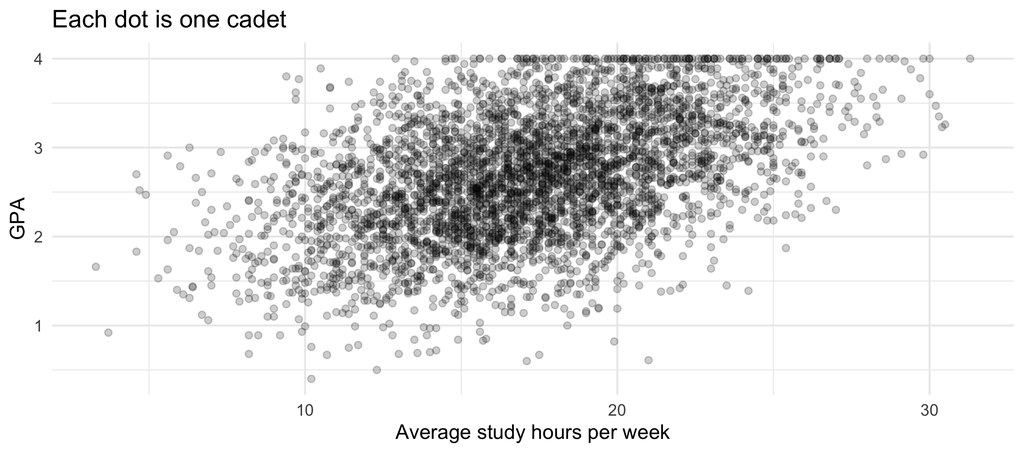

**Form:** linear · **Direction:** positive · **Strength:** moderate

# Correlation

Putting a number on strength and direction

## Correlation $r$: what it tells us, and what it doesn’t

The **correlation** $r$ measures the **strength and direction of the linear relationship** between two numerical variables.

$$r = \frac{1}{n-1}\sum_{i=1}^{n}\left(\frac{x_i - \bar{x}}{s_x}\right)\left(\frac{y_i - \bar{y}}{s_y}\right)
\qquad -1 \le r \le 1$$

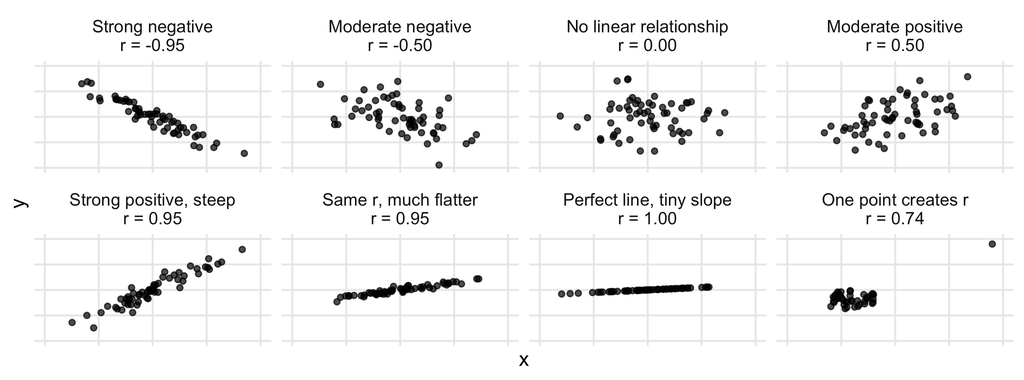

**Tells us:** direction (sign) and how tightly the points hug a line.

**Doesn’t tell us:** how **steep** the line is, or whether one point is doing all the work

## Our cadets: $r$ for study hours and GPA

```r
cadets |> summarize(r = cor(gpa, avg_study_hours))
```

```
# A tibble: 1 × 1
      r
  <dbl>
1 0.468
```

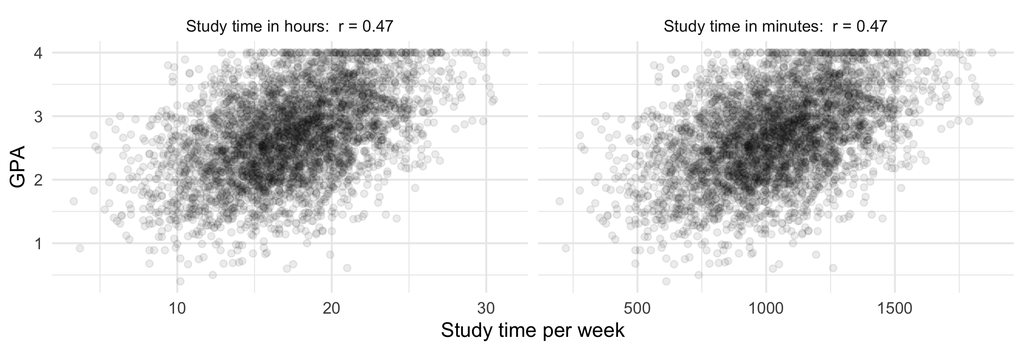

$r$ is between −1 and +1: **sign** = direction, **closer to ±1** = closer to a line. Change the units and **$r$ does not change**.

## $r$ only measures **linear** relationships

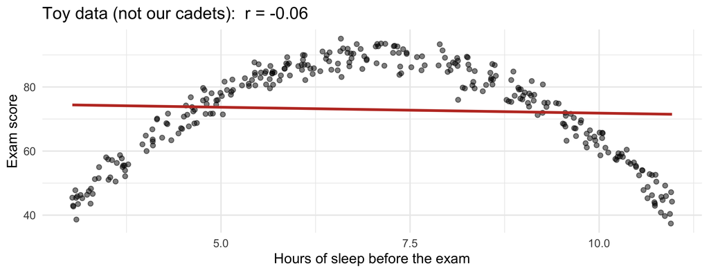

A **strong** relationship can have $r \approx 0$ if it isn’t a line. **Always plot first.**

# Finding the Best Line

Population line · Sample estimate · Residuals · Least squares

## The population line

### General form

$$y = \beta_0 + \beta_1 x + \epsilon$$

$\beta_0$ intercept, $\beta_1$ slope, $\epsilon$ = random **error** (how far an individual falls from the line)

### Our population: all 4,035 cadets

$$\text{GPA} = 1.339 + 0.0777 \times \text{hours} + \epsilon$$

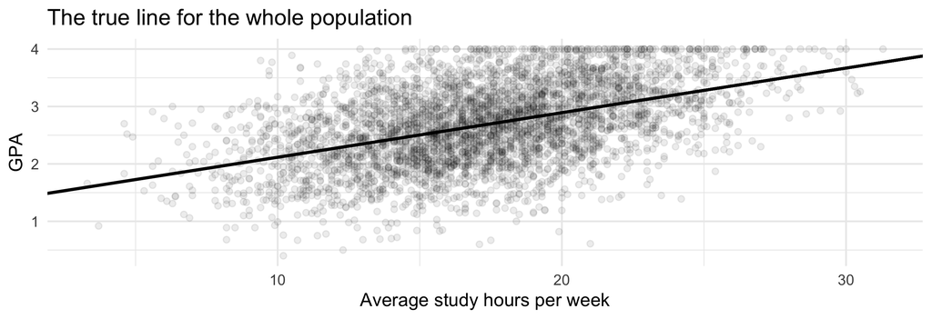

In real life we **never** see this line. Here we can, because we simulated every cadet.

## Estimating the line from a sample

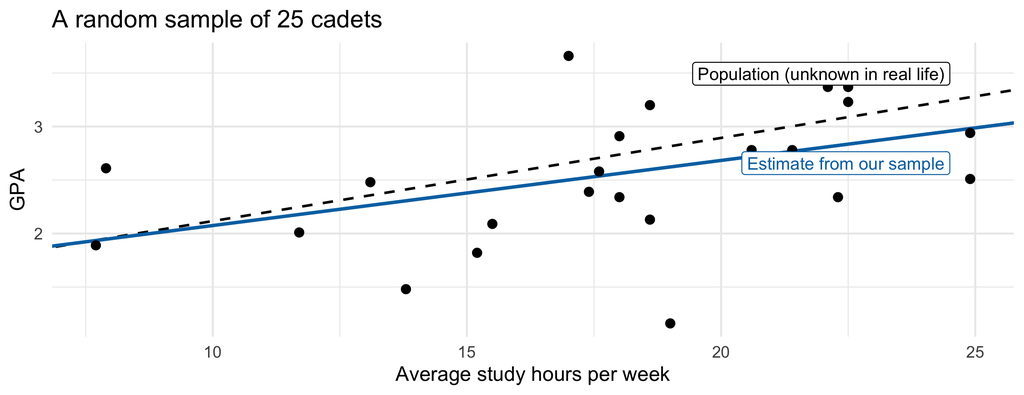

$$\hat{y} = b_0 + b_1 x
\qquad\longrightarrow\qquad
\widehat{\text{GPA}} = 1.466 + 0.0609 \times \text{hours}$$

We estimate $b_0$ and $b_1$ with **ordinary least squares (OLS)** · a different sample gives a different line

## Residual: how far a cadet is from the line

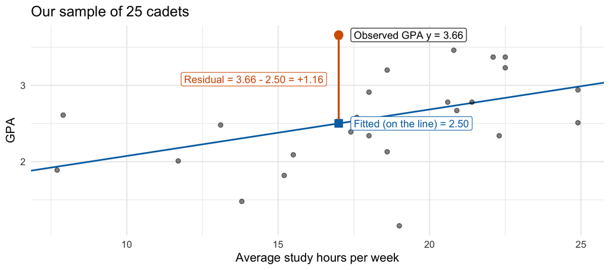

$$\hat{y} = 1.466 + 0.0609 \times x
\quad\Rightarrow\quad
\hat{y} = 1.466 + 0.0609(17) = 2.50$$

**Residual** = observed − fitted = $y - \hat{y}$ · above the line (+), below the line (−)

## Which line is best?

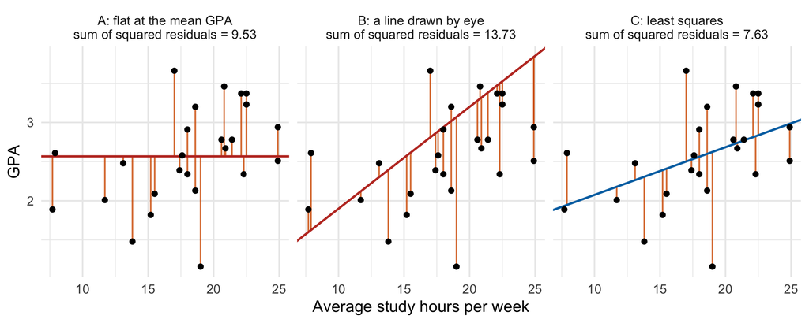

The **ordinary least squares (OLS) line** makes $e_1^2 + e_2^2 + \cdots + e_n^2$ as **small as possible**

# Interpreting the Line

Fit in R · Slope · Intercept · Predictions · Extrapolation

## Fitting the line in R and reading the slope

```r
model <- lm(gpa ~ avg_study_hours,
            data = cadets)
coef(model)
```

```
    (Intercept) avg_study_hours
     1.33926184      0.07772248
```

$$\widehat{\text{GPA}} = 1.339 + 0.0777 \times \text{hours}$$

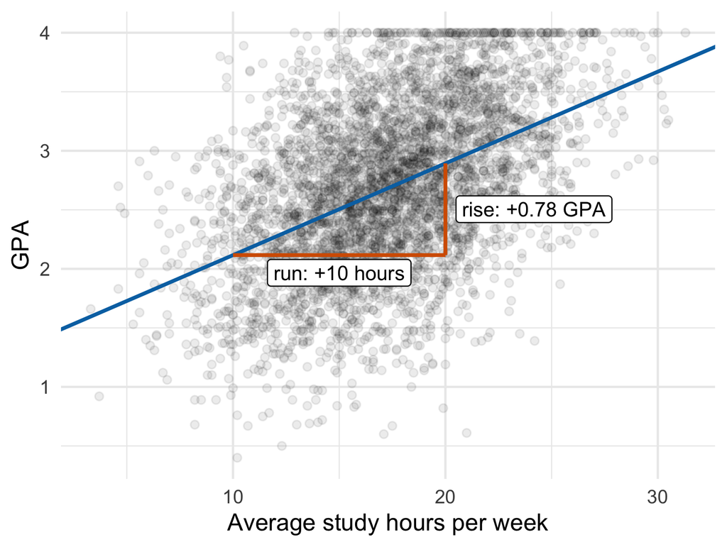

```r
ggplot(cadets, aes(x = avg_study_hours,
                   y = gpa)) +
  geom_point(alpha = 0.2) +
  geom_smooth(method = "lm", se = FALSE)
```

**Slope:** for each additional hour of study per week, GPA is **0.078 points higher, on average**.

## The intercept

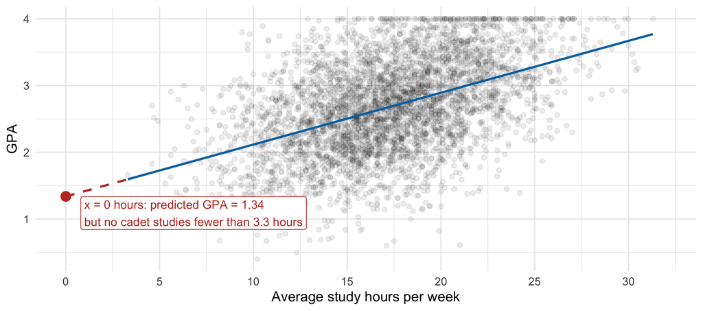

Intercept = average $y$ when $x = 0$ · **only meaningful if** $x = 0$ **makes sense and is in the data**

## The “silliest” model: no predictor

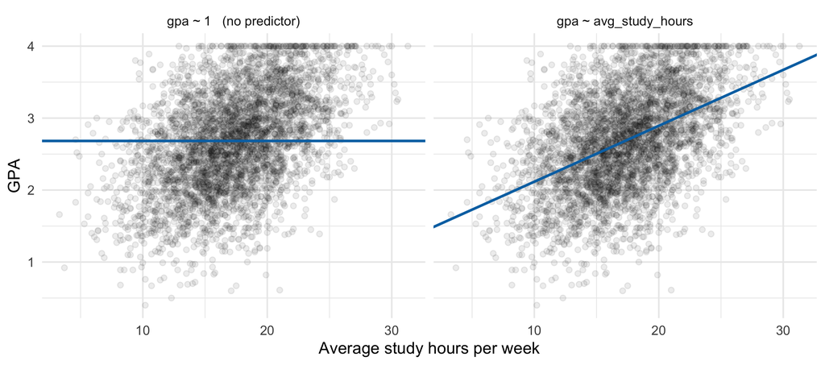

`lm(gpa ~ 1)` gives intercept **2.683** = the mean GPA. Adding study hours lets the line **tilt**.

## Predictions are averages

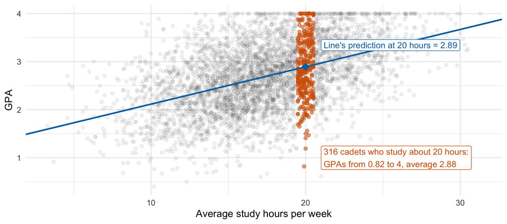

$$\widehat{\text{GPA}} = 1.339 + 0.0777(20) = 2.89$$

Cadets who study 20 hours a week have a **predicted average** GPA of 2.89.

## Extrapolation: stay inside the data

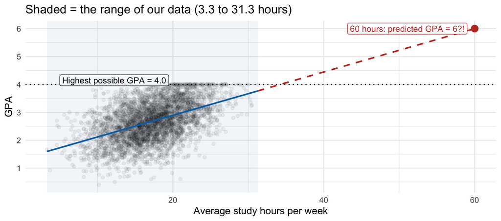

**Extrapolation**: using the line outside the range of the data. The line has no idea what happens out there.

## Correlation is not causation

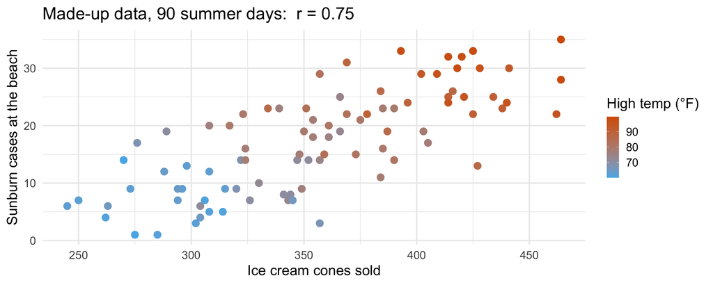

Ice cream doesn’t cause sunburns. **Hot, sunny days** drive both: a **confounding variable**.

## Bonus: a residual is a **vertical** distance

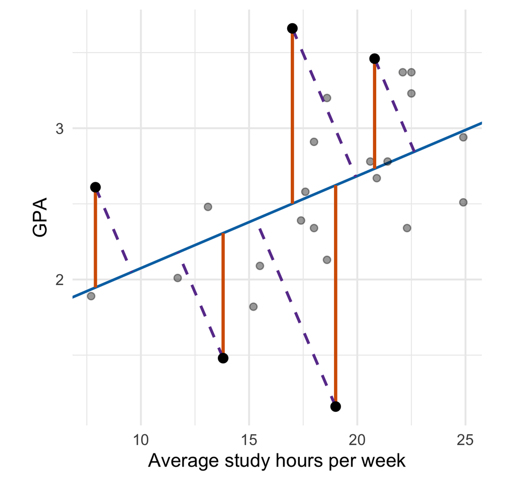

**Solid orange: residual** $y - \hat{y}$

Straight **up or down** to the line. It’s the error in our **prediction of GPA**, in GPA units. Least squares minimizes these.

**Dashed purple: perpendicular distance**

The **shortest** path to the line, at a right angle. It’s what we tend to eyeball when we draw a line by hand. Regression does **not** use it.